# Graphs in Base R: Scatter Plots

⇦ Back

# 1 How Do I Create a Scatter Plot?

## 1.1 Using Vectors

The easiest way to create a scatter plot in R is by using the `plot()` function:

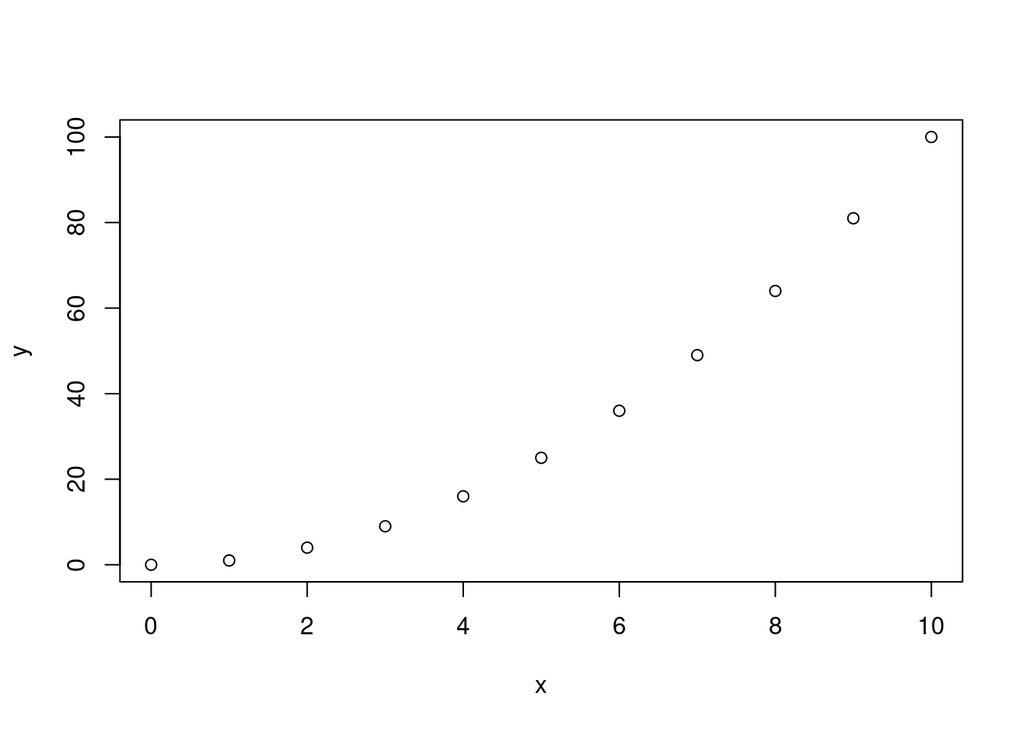

```r
x <- c(0, 1, 2, 3, 4, 5, 6, 7, 8, 9, 10)
y <- c(0, 1, 4, 9, 16, 25, 36, 49, 64, 81, 100)
plot(x, y)
```

As you can see above, the x-data is a vector of numbers and the y-data is also a vector of numbers.

## 1.2 Using Data Frames

If you are coding in R you will mostly be working with **data frames**. Remember that data frames are essentially tables where the *columns are vectors*, so two columns of a data frames can be plotted against each other very easily! Let’s use one of the pre-loaded data frames that comes packaged with R; the Anscombe dataset:

```r
print(anscombe)
```

```
##    x1 x2 x3 x4    y1   y2    y3    y4
## 1  10 10 10  8  8.04 9.14  7.46  6.58
## 2   8  8  8  8  6.95 8.14  6.77  5.76
## 3  13 13 13  8  7.58 8.74 12.74  7.71
## 4   9  9  9  8  8.81 8.77  7.11  8.84
## 5  11 11 11  8  8.33 9.26  7.81  8.47
## 6  14 14 14  8  9.96 8.10  8.84  7.04
## 7   6  6  6  8  7.24 6.13  6.08  5.25
## 8   4  4  4 19  4.26 3.10  5.39 12.50
## 9  12 12 12  8 10.84 9.13  8.15  5.56
## 10  7  7  7  8  4.82 7.26  6.42  7.91
## 11  5  5  5  8  5.68 4.74  5.73  6.89
```

As you can see there are four columns of x-values (x1, x2, x3, x4) and four columns of y-values (y1, y2, y3, y4). Let’s plot each of them:

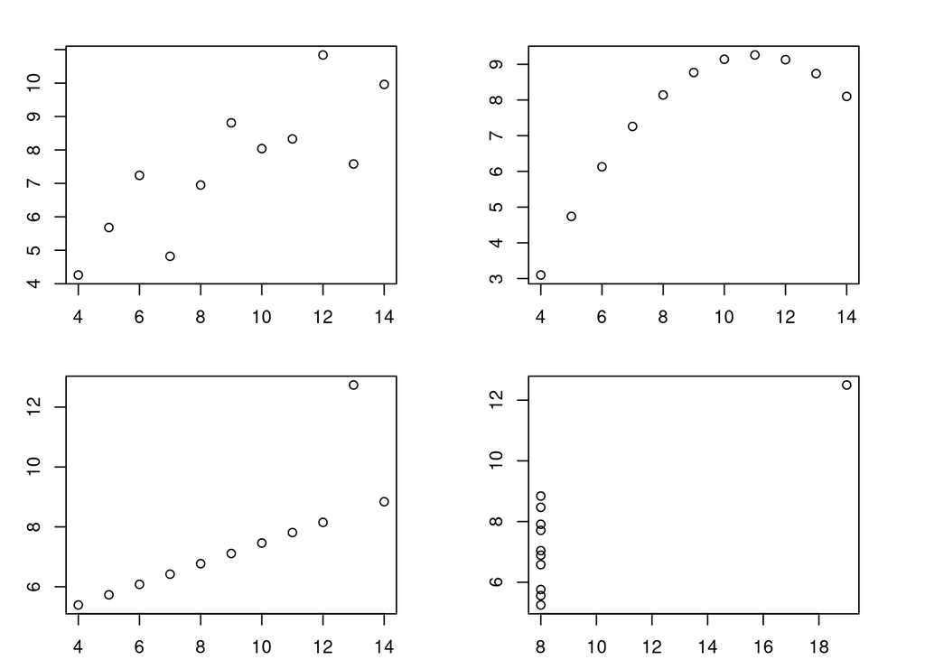

```r
plot(anscombe$x1, anscombe$y1)
plot(anscombe$x2, anscombe$y2)
plot(anscombe$x3, anscombe$y3)
plot(anscombe$x4, anscombe$y4)
```

The Anscombe Quartet is an interesting dataset to use because it consists of four plots that have near-identical descriptive statistics, despite looking very different when graphed.

# 2 Axis Titles

The function `plot()` can take **keyword arguments**, some of which are:

- `main` which sets the main title of the graph
- `xlab` which sets the x-axis label
- `ylab` which sets the y-axis label

Here’s what it looks like:

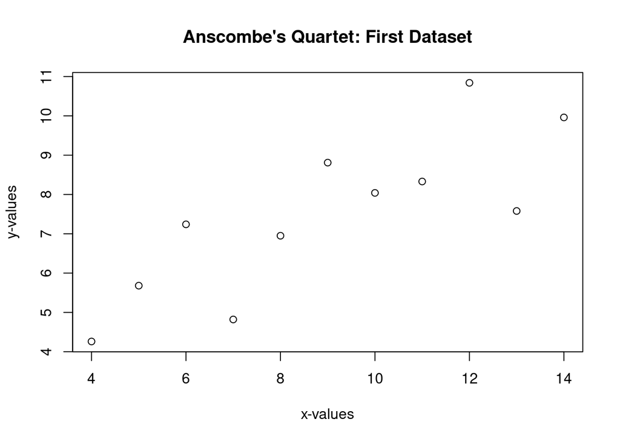

```r
plot(
    anscombe$x1, anscombe$y1,
    main = "Anscombe's Quartet: First Dataset",
    xlab = "x-values", ylab = "y-values"
)
```

## 2.1 Unicode in Axis Titles

If you are plotting scientific or mathematical results you might need to indicate units or symbols that are outside of the normal Latin alphabet. In these instances you can incorporate Unicode by using the `\U` Unicode indicator:

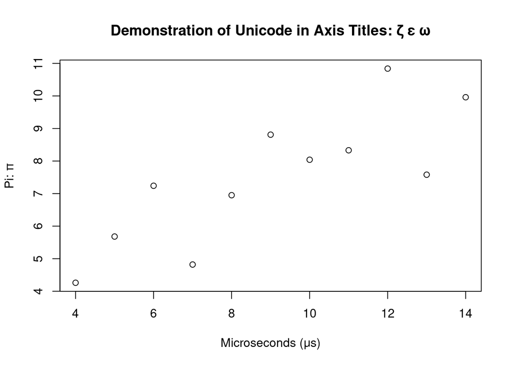

```r
plot(
    anscombe$x1, anscombe$y1,
    main = "Demonstration of Unicode in Axis Titles: \U03B6 \U03B5 \U03C9",
    xlab = "Microseconds (\U03BCs)", ylab = "Pi: \U03C0"
)
```

# 3 Axis Options

The limits of the x- and y-axes can be changed with the `xlim` and `ylim` keyword arguments. Decide what you want the max and min values of the axes to be and specify these as vectors:

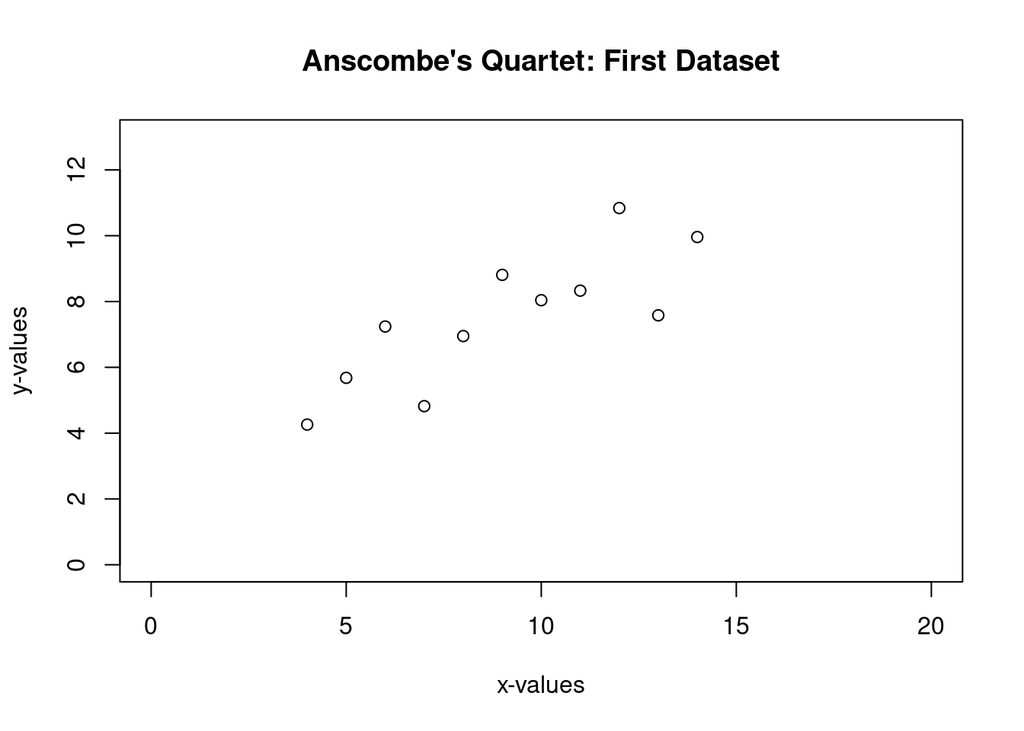

```r
plot(
    anscombe$x1, anscombe$y1,
    main = "Anscombe's Quartet: First Dataset",
    xlab = "x-values", ylab = "y-values",
    xlim = c(0, 20), ylim = c(0, 13)
)
```

You can also plot on a log axis if you want. Use the `log` keyword argument:

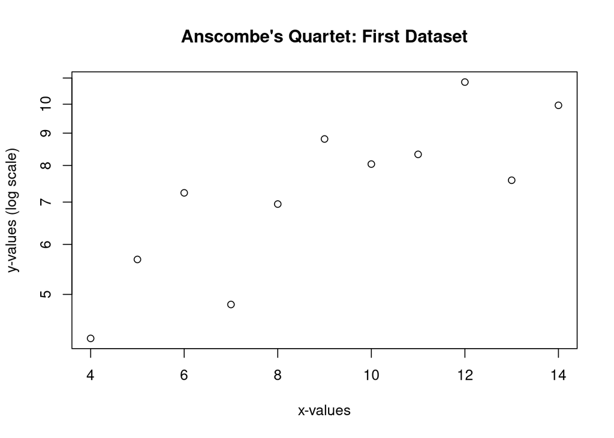

```r
plot(
    anscombe$x1, anscombe$y1,
    main = "Anscombe's Quartet: First Dataset",
    xlab = "x-values", ylab = "y-values (log scale)",
    log = "y"
)
```

# 4 Plot Symbols

The symbol that is used for the plot points can be changed using the `pch` (**p**oint **ch**aracter) keyword argument. There are 26 symbols that can be used this way. For example, if we want to use squares for the plot instead of circles we can do that by setting `pch` to zero:

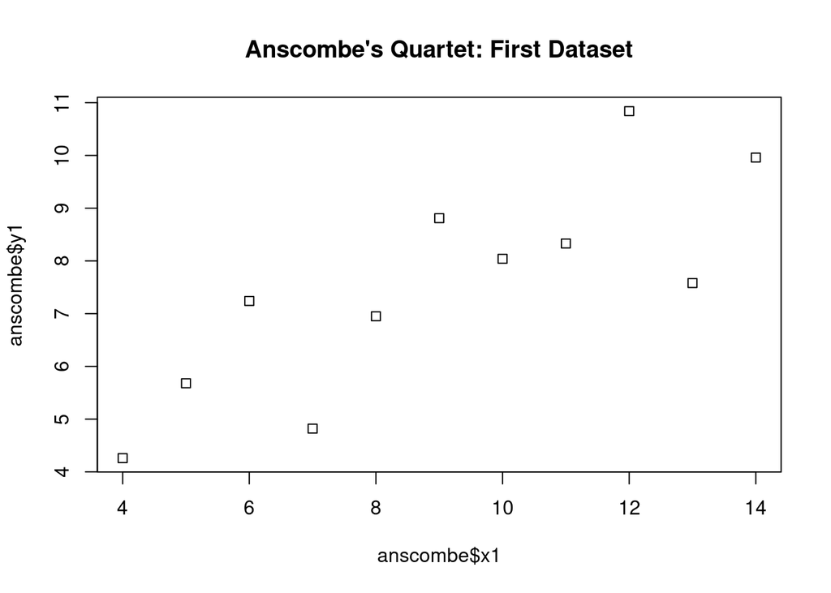

```r
plot(
    anscombe$x1, anscombe$y1,
    main = "Anscombe's Quartet: First Dataset",
    pch = 0
)
```

For a full list of what symbols can be used, click here.

# 5 Plot Colours

Change the colour of the plot symbols using the `col` keyword argument:

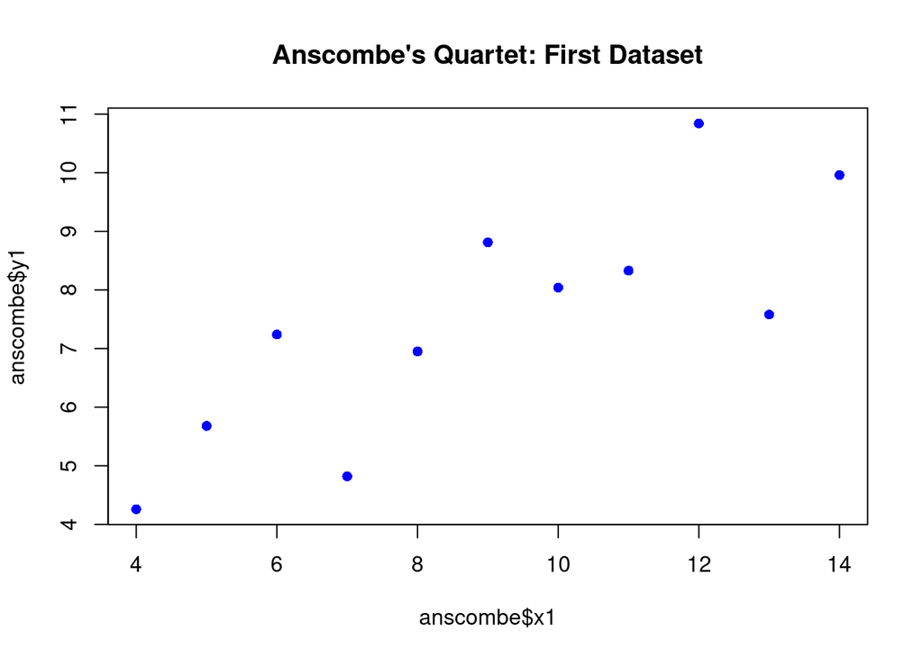

```r
plot(
    anscombe$x1, anscombe$y1,
    main = "Anscombe's Quartet: First Dataset",
    col = "blue", pch = 16
)
```

# 6 Multiple Plots on the Same Axes

In order to plot multiple sets of data on the same axes, use the `points()` function for the additional datasets:

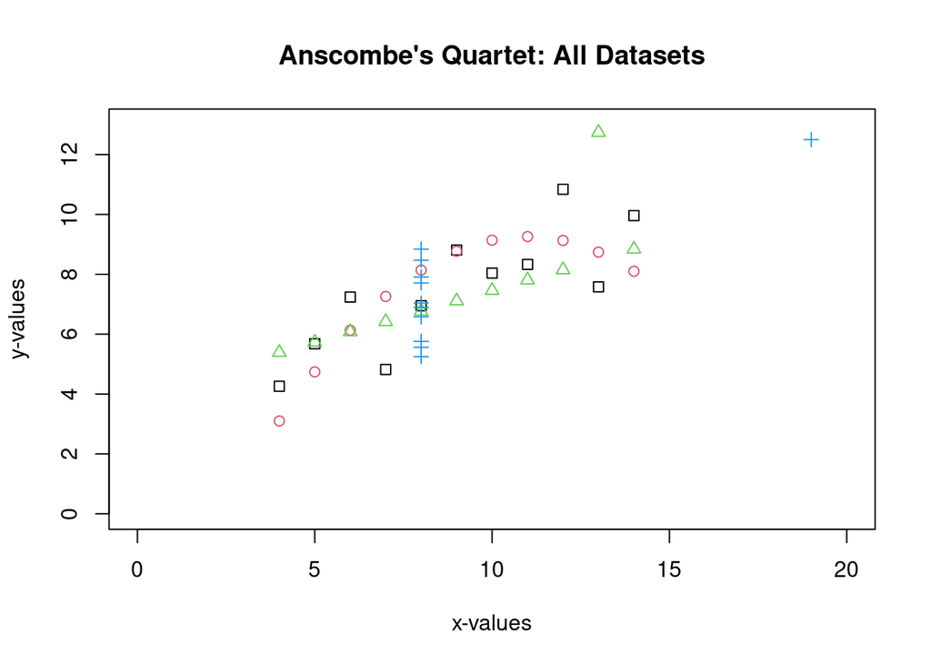

```r
# The first dataset is plotted using plot()
plot(
    anscombe$x1, anscombe$y1,
    main = "Anscombe's Quartet: All Datasets",
    pch = 0, col = 1,
    xlab = "x-values", ylab = "y-values",
    xlim = c(0, 20), ylim = c(0, 13)
)
# The additional datasets are plotted using points()
points(anscombe$x2, anscombe$y2, pch = 1, col = 2)
points(anscombe$x3, anscombe$y3, pch = 2, col = 3)
points(anscombe$x4, anscombe$y4, pch = 3, col = 4)
```

This is where the usefulness of having different plot symbols and different plot colours becomes apparent. If all four of these datasets were plotted with the same colour and had the same symbol, it would be impossible to tell them apart!

## 6.1 Legends

With all these datasets being plotted, we’d better use a legend to identify them:

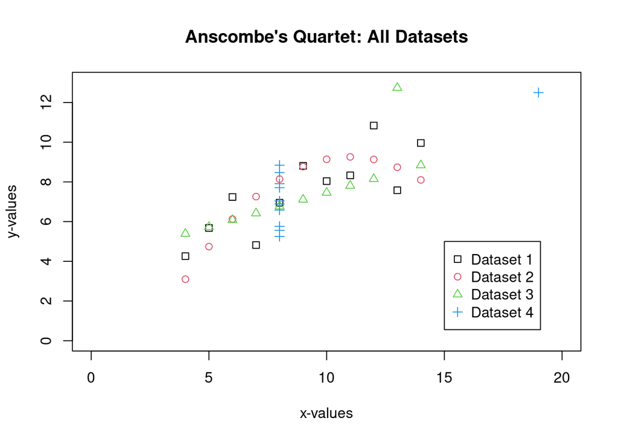

```r
# The first dataset is plotted using plot()
plot(
    anscombe$x1, anscombe$y1,
    main = "Anscombe's Quartet: All Datasets",
    pch = 0, col = 1,
    xlab = "x-values", ylab = "y-values",
    xlim = c(0, 20), ylim = c(0, 13)
)
# The additional datasets are plotted using points()
points(anscombe$x2, anscombe$y2, pch = 1, col = 2)
points(anscombe$x3, anscombe$y3, pch = 2, col = 3)
points(anscombe$x4, anscombe$y4, pch = 3, col = 4)
# Include a legend
legend(
    15, 5,
    c("Dataset 1", "Dataset 2", "Dataset 3", "Dataset 4"),
    pch = c(0, 1, 2, 3),
    col = c(1, 2, 3, 4)
)
```

# 7 Add a Regression Line

To add a ‘line of best fit’, use the `lm()` (**l**inear **m**odel) function then the `abline()` function (which plots a straight **line** between **a** and **b**). Note that the `lm()` function uses the tilde notation (`lm(y ~ x)`) and so the y-variable must go on the left of the tilde and the x-variable on the right. This is the opposite of the `plot(x, y)` format which requires that the x-variable comes first.

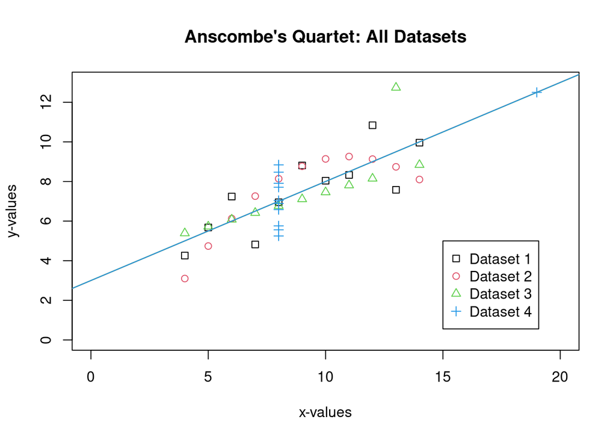

```r
# The first dataset is plotted using plot()
plot(
    anscombe$x1, anscombe$y1,
    main = "Anscombe's Quartet: All Datasets",
    pch = 0, col = 1,
    xlab = "x-values", ylab = "y-values",
    xlim = c(0, 20), ylim = c(0, 13),
)
# The additional datasets are plotted using points()
points(anscombe$x2, anscombe$y2, pch = 1, col = 2)
points(anscombe$x3, anscombe$y3, pch = 2, col = 3)
points(anscombe$x4, anscombe$y4, pch = 3, col = 4)
# Plot lines of best fit
abline(lm(anscombe$y1 ~ anscombe$x1), col = 1)
abline(lm(anscombe$y2 ~ anscombe$x2), col = 2)
abline(lm(anscombe$y3 ~ anscombe$x3), col = 3)
abline(lm(anscombe$y4 ~ anscombe$x4), col = 4)
# Include a legend
legend(
    15, 5,
    c("Dataset 1", "Dataset 2", "Dataset 3", "Dataset 4"),
    pch = c(0, 1, 2, 3),
    col = c(1, 2, 3, 4)
)
```

Notice that all four lines of best fit are exactly the same! We can only see one straight line because the other three are hidden underneath it. This is what is so interesting about the Anscombe Quartet of datasets that we used; despite the fact that they look so different when plotted the statistics that describe them are almost identical!

# 8 More Options

There are many more options that can be tweaked in order to customise your plot and have it look exactly how you want it. Here are some of them:

- Using the `par()` function to set general graphical **par**ameters:
  - `par(pin = c(width, height))` will set the dimensions of the plot in inches (so divide by 25.4 to convert to centimetres, eg `par(pin = c(20 / 25.4, 15 / 25.4))` will create a graph 20 cm in width and 15 cm in height)
  - `par(plt = c(xstart, xend, ystart, yend))` will set the dimensions of the graph inside of the plot area (ie it will change the amount of white space around the plot). It does this using fractions of the figure region, so `par(plt = c(0.2, 0.98, 0.2, 0.85))` will have the plot area start 20% of the way in from the left-hand side of the image and run until 98% of the way to the right-hand side of the image and, similarly, it will start 20% of the way up from the bottom and end 85% of the way up to the top of the image.
- Using additional keyword arguments inside `plot()`:
  - `plot(x, y, frame = FALSE)` will remove the border around the graph
  - `plot(x, y, asp = 2)` will set the aspect ratio of the plot to, in this case 2:1 (height:width)

# 9 Save Plot

Finally, save your plot to your computer as an image using `png("Name of Plot.png")`.

⇦ Back